# WDA Student Workshop 2025: Part 2 Spatial Analysis

2025-07-21

### Outline

The sections of this workshop R script/R markdown are as follows:

1. **Spatial Data Basics**
- Import Data
- Data Cleaning and Introduction to Piping
- Convert to a Spatial Data Object Type using Sf
- Visualizing Our Spatial Data
- Importance of Matching Projections
2. **Working with Geometric Operations in Sf**
- Creating a Spatial Grid (this is as far as we will attempt to get for today)
- Working with Raster and Vector Data
- Working with Vector and Vector Data
3. **Assessing Correlation**
- Checking for simple correlation between species data and and covariate data
- Checking for spatial autocorrelation in the temperature covariate

### Data

We are working primarily with the species occurrence dataset from Global Biodiversity Facility Information (GBIF) but there is extra code for the World Clim habitat data.

- *sp* - a dataframe containing species occurrence information from aggregated sources (raw data is stored as a TSV or tab separated value)
- *World Clim: Precipitation and Temperature* - yearly average for each month of the year between 1970–2000 (raw data is stored as geotifs)

### Load Libraries

```r
library(tidyverse)
library(sf)
library(terra)
library(CoordinateCleaner)
library(rnaturalearth)
library(units)
library(spdep)
```

## Spatial Data Basics:

### Import Data

```r
sp<-read.delim("data_raw/dicamptodon_tenebrosus_gbif/dicamptodon_tenebrosus_gbif.csv",sep = "\t", stringsAsFactors = T)
```

### Data Cleaning and Introduction to Piping

```r
  sp_clean <- sp %>%

    filter(occurrenceStatus  == "PRESENT") %>%

    filter(!basisOfRecord %in% c("FOSSIL_SPECIMEN","LIVING_SPECIMEN","MATERIAL_SAMPLE","MATERIAL_CITATION")) %>%

    filter(year >= 1994) %>%

    mutate(coordinateUncertaintyInMeters = case_when(coordinateUncertaintyInMeters %in% c(301,3036,999,9999) ~ NA,T ~ coordinateUncertaintyInMeters)) %>%

    filter(coordinateUncertaintyInMeters <= 3000) %>%

    filter(!decimalLatitude == 0 | !decimalLongitude == 0) %>%

    cc_cen(buffer = 2000) %>%

    cc_cap(buffer = 2000) %>%

    cc_inst(buffer = 2000) %>%

    cc_sea() %>%

    distinct(decimalLongitude, decimalLatitude, speciesKey, datasetKey, .keep_all = TRUE)
```

```
## Testing sea coordinates
```

```
## Testing biodiversity institutions
```

```
## Testing country capitals
```

```
## Testing country centroids
```

```
## Removed 0 records.
## Removed 0 records.
```

```
## Removed 465 records.
```

```
## Removed 67 records.
```

### Convert to a Spatial Data Object Type using Sf

Here we convert our data frame into an sf spatial data object. It converts the coordinate columns (latitude and longitude) into a single column that contains individual point geometries.

```r
class(sp_clean)
```

```
## [1] "data.frame"
```

```r
sp_clean_sf<-st_as_sf(sp_clean,coords = c("decimalLongitude", "decimalLatitude"),crs = 4326)



sp_clean_sf
```

```
## Simple feature collection with 1136 features and 48 fields
## Geometry type: POINT
## Dimension:     XY
## Bounding box:  xmin: -124.4394 ymin: 39.05962 xmax: -120.8882 ymax: 49.18327
## Geodetic CRS:  WGS 84
## First 10 features:
##        gbifID                           datasetKey
## 1   899972277 50c9509d-22c7-4a22-a47d-8c48425ef4a7
## 2   891745555 50c9509d-22c7-4a22-a47d-8c48425ef4a7
## 3   891745521 50c9509d-22c7-4a22-a47d-8c48425ef4a7
## 4   891167816 50c9509d-22c7-4a22-a47d-8c48425ef4a7
## 5  5198909104 50c9509d-22c7-4a22-a47d-8c48425ef4a7
## 6  5198903768 50c9509d-22c7-4a22-a47d-8c48425ef4a7
## 7  5198705305 50c9509d-22c7-4a22-a47d-8c48425ef4a7
## 8  5198490028 50c9509d-22c7-4a22-a47d-8c48425ef4a7
```

[output cut: 145 more lines]

```r
class(sp_clean_sf)
```

```
## [1] "sf"         "data.frame"
```

```r
str(sp_clean_sf)
```

```
## Classes 'sf' and 'data.frame':   1136 obs. of  49 variables:
##  $ gbifID                          : num  9.00e+08 8.92e+08 8.92e+08 8.91e+08 5.20e+09 ...
##  $ datasetKey                      : Factor w/ 32 levels "02242d2f-b43f-44d1-8e53-4c51af461f5b",..: 9 9 9 9 9 9 9 9 9 9 ...
##  $ occurrenceID                    : Factor w/ 6042 levels "","16290170-a849-4707-86e4-d0b815502cfc",..: 687 669 670 653 4141 4136 4142 4139 4140 4133 ...
##  $ kingdom                         : Factor w/ 1 level "Animalia": 1 1 1 1 1 1 1 1 1 1 ...
##  $ phylum                          : Factor w/ 1 level "Chordata": 1 1 1 1 1 1 1 1 1 1 ...
##  $ class                           : Factor w/ 1 level "Amphibia": 1 1 1 1 1 1 1 1 1 1 ...
##  $ order                           : Factor w/ 1 level "Caudata": 1 1 1 1 1 1 1 1 1 1 ...
##  $ family                          : Factor w/ 1 level "Ambystomatidae": 1 1 1 1 1 1 1 1 1 1 ...
##  $ genus                           : Factor w/ 1 level "Dicamptodon": 1 1 1 1 1 1 1 1 1 1 ...
##  $ species                         : Factor w/ 1 level "Dicamptodon tenebrosus": 1 1 1 1 1 1 1 1 1 1 ...
##  $ infraspecificEpithet            : logi  NA NA NA NA NA NA ...
##  $ taxonRank                       : Factor w/ 1 level "SPECIES": 1 1 1 1 1 1 1 1 1 1 ...
##  $ scientificName                  : Factor w/ 3 levels "Ambystoma tenebrosum Baird & Girard, 1852",..: 3 3 3 3 3 3 3 3 3 3 ...
##  $ verbatimScientificName          : Factor w/ 4 levels "Ambystoma tenebrosum",..: 3 3 3 3 3 3 3 3 3 3 ...
```

[output cut: 38 more lines]

### Visualizing Our Spatial Data

Here we visualize our data and change the plotting window limits to to match the boundaries of our species data points.

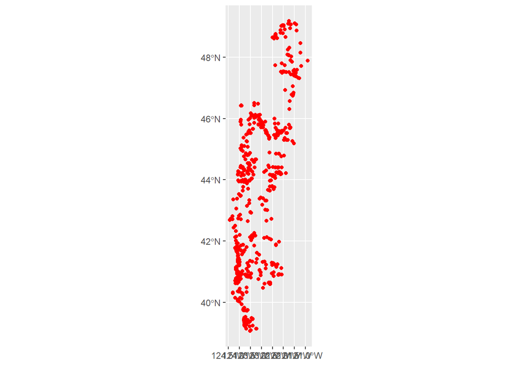

```r
##Initial Plot


ggplot()+
  geom_sf(data=sp_clean_sf,colour="red")
```

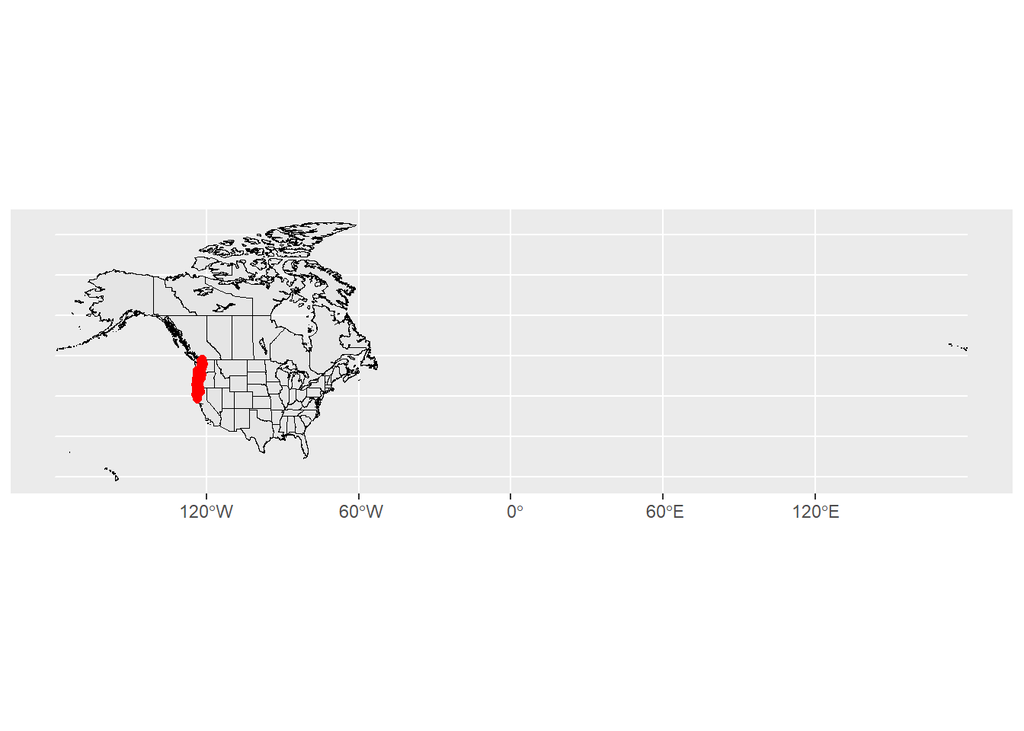

```r
st <- ne_states(country = c("Canada","United States of America"),
                                 returnclass = "sf")


ggplot()+
  geom_sf(data=st,colour="black")+
  geom_sf(data=sp_clean_sf,colour="red")
```

```r
##Zooming In


bb <- st_bbox(sp_clean_sf)
bb
```

```
##       xmin       ymin       xmax       ymax
## -124.43941   39.05962 -120.88818   49.18327
```

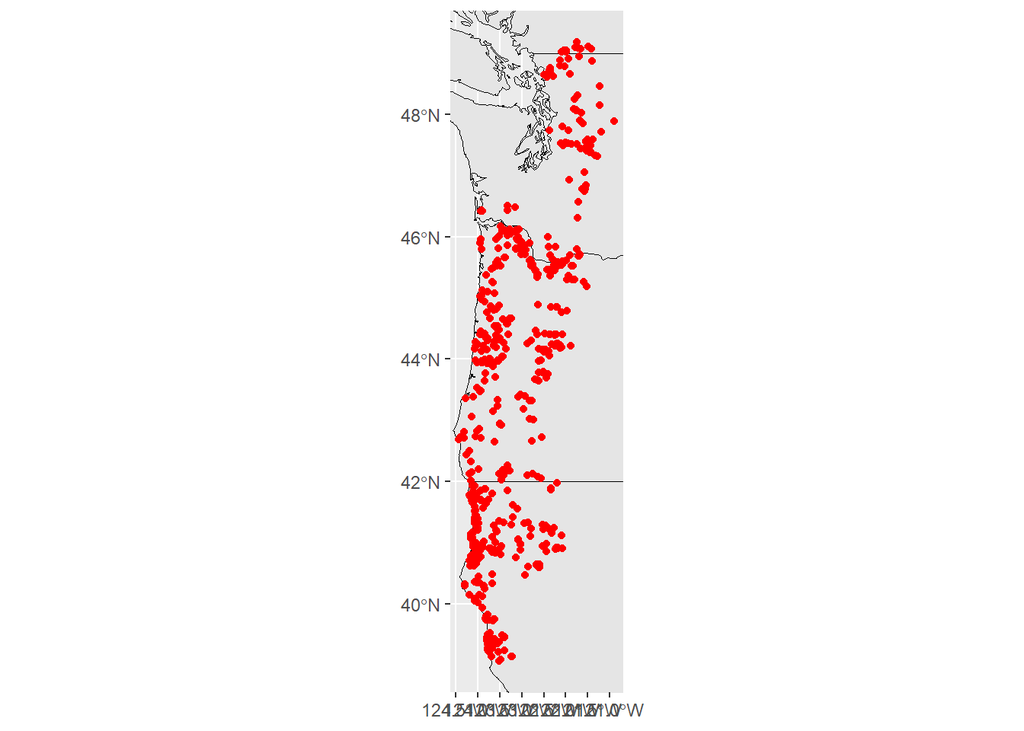

```r
ggplot()+
  geom_sf(data=st,colour="black")+
  geom_sf(data=sp_clean_sf,colour="red")+
    coord_sf(xlim = bb[c("xmin", "xmax")], ylim = bb[c("ymin", "ymax")])
```

### Importance of Matching Projections

Here we change our species data points into a projection that preserves area, confirm the mismatch in projections between the state and species data, and then subsequently change the state data to the same projection as the species data.

```r
## Checks


sp_clean_sf<-sp_clean_sf%>%
st_transform(crs = 5070)

crs(sp_clean_sf)
```

```
## [1] "PROJCRS[\"NAD83 / Conus Albers\",\n    BASEGEOGCRS[\"NAD83\",\n        DATUM[\"North American Datum 1983\",\n            ELLIPSOID[\"GRS 1980\",6378137,298.257222101,\n                LENGTHUNIT[\"metre\",1]]],\n        PRIMEM[\"Greenwich\",0,\n            ANGLEUNIT[\"degree\",0.017453292519…
```

```r
crs(st)
```

```
## [1] "GEOGCRS[\"WGS 84\",\n    DATUM[\"World Geodetic System 1984\",\n        ELLIPSOID[\"WGS 84\",6378137,298.257223563,\n            LENGTHUNIT[\"metre\",1]]],\n    PRIMEM[\"Greenwich\",0,\n        ANGLEUNIT[\"degree\",0.0174532925199433]],\n    CS[ellipsoidal,2],\n        AXIS[\"geodetic latitu…
```

```r
crs(st)==crs(sp_clean_sf)
```

```
## [1] FALSE
```

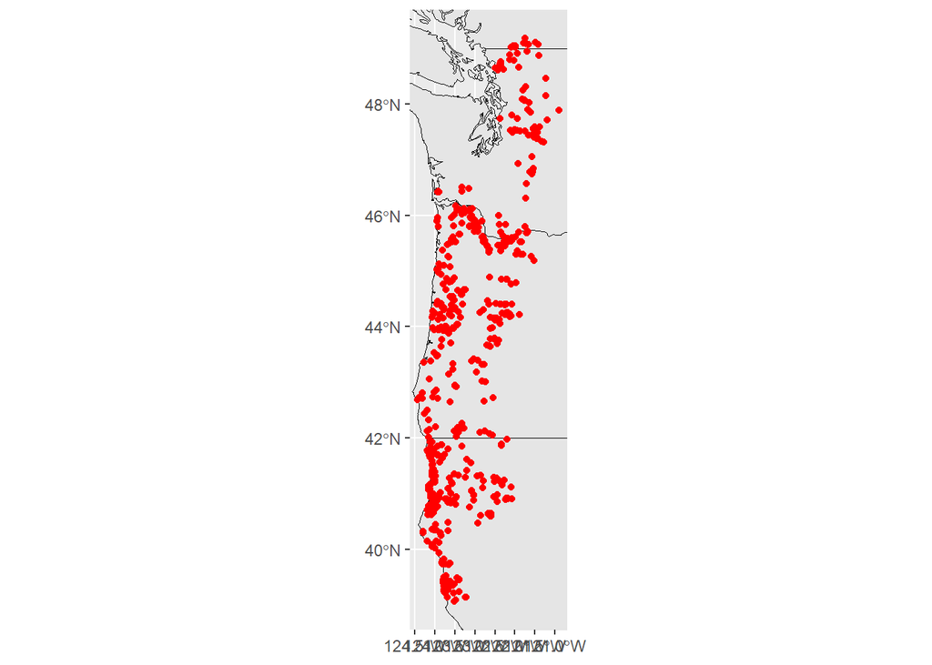

```r
##Plots


ggplot()+
  geom_sf(data=st,colour="black")+
  geom_sf(data=sp_clean_sf,colour="red")+
    coord_sf(xlim = bb[c("xmin", "xmax")], ylim =  bb[c("ymin", "ymax")])
```

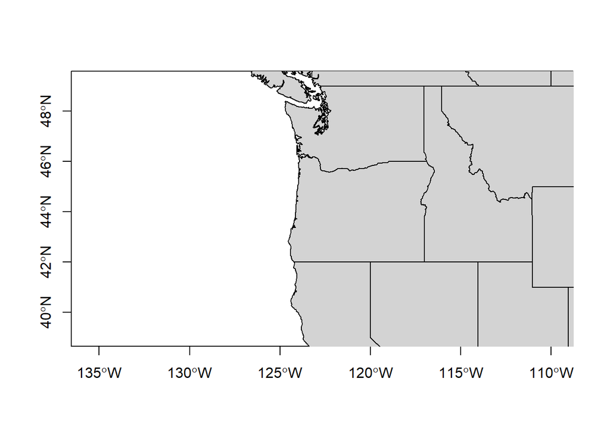

```r
plot(sf::st_geometry(st), col = "lightgrey", xlim = bb[c("xmin", "xmax")], ylim = bb[c("ymin", "ymax")], axes = TRUE)
plot(sf::st_geometry(sp_clean_sf), col = "red",add = TRUE)
```

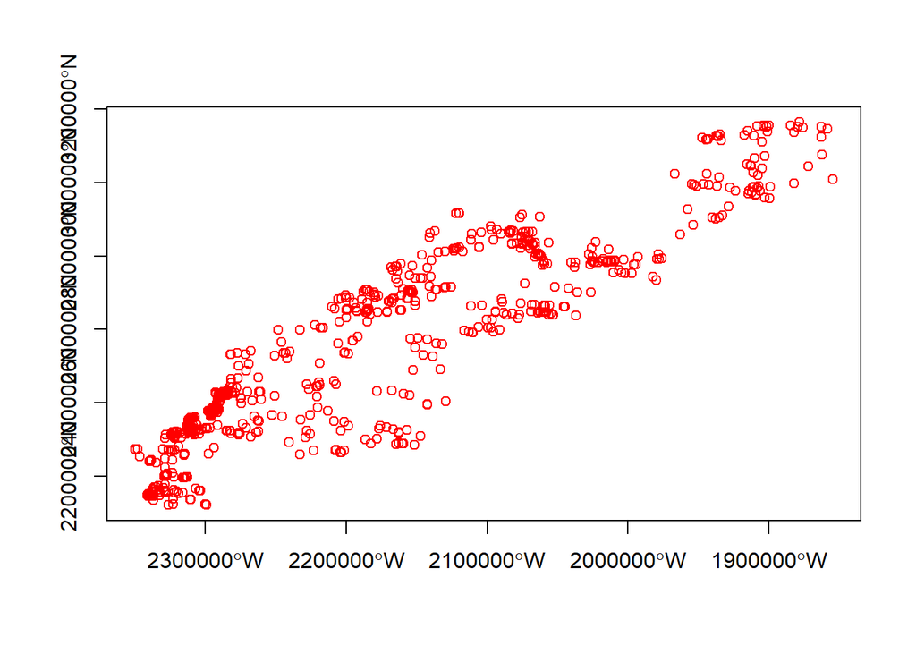

```r
bb <- st_bbox(sp_clean_sf)
plot(sf::st_geometry(st), col = "lightgrey", xlim = bb[c("xmin", "xmax")], ylim = bb[c("ymin", "ymax")], axes = TRUE)
plot(sf::st_geometry(sp_clean_sf), col = "red",add = TRUE)
```

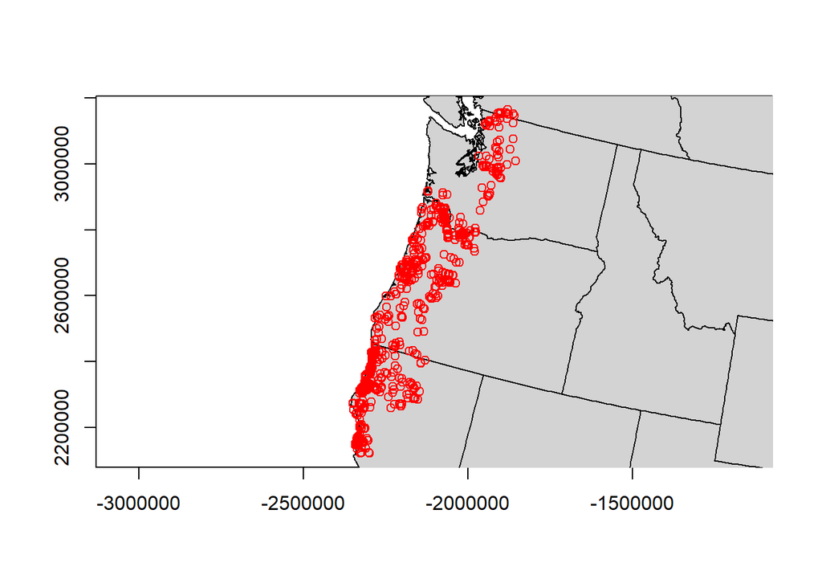

```r
## Fix


st<-st%>%
st_transform(crs = 5070)


bb <- st_bbox(sp_clean_sf)
plot(sf::st_geometry(st), col = "lightgrey", xlim = bb[c("xmin", "xmax")], ylim = bb[c("ymin", "ymax")], axes = TRUE)
plot(sf::st_geometry(sp_clean_sf), col = "red",add = TRUE)
```

## Working with Geometric Operations in Sf:

### Creating a Spatial Grid

Here we change our multiple point geometries into one multipoint geometry to create a unified convex polygon. The convex polygon is then used to create a “species range” that we use as the range over which we build a spatial grid.

```r
##Convex Hull


sp_clean_sf_multi<-st_union(sp_clean_sf)
sp_clean_sf_multi
```

```
## Geometry set for 1 feature
## Geometry type: MULTIPOINT
## Dimension:     XY
## Bounding box:  xmin: -2350083 ymin: 2120733 xmax: -1854629 ymax: 3164330
## Projected CRS: NAD83 / Conus Albers
```

```
## MULTIPOINT ((-2350083 2272672), (-2349653 22723...
```

```r
sp_clean_sf_hull<-st_buffer(st_convex_hull(sp_clean_sf_multi),10000)

sp_clean_sf_hull
```

```
## Geometry set for 1 feature
## Geometry type: POLYGON
## Dimension:     XY
## Bounding box:  xmin: -2360082 ymin: 2110736 xmax: -1844632 ymax: 3174329
## Projected CRS: NAD83 / Conus Albers
```

```
## POLYGON ((-2325888 2110738, -2326409 2110736, -...
```

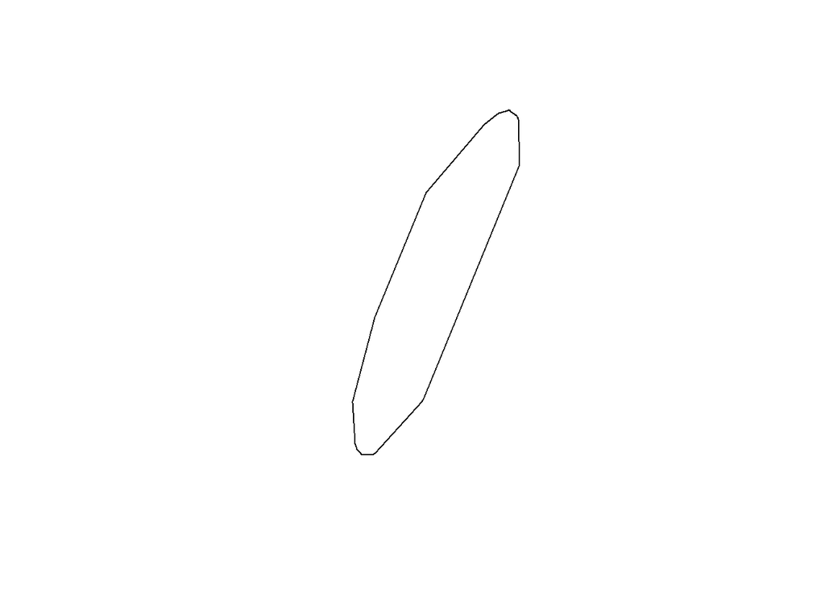

```r
plot(sp_clean_sf_hull)
```

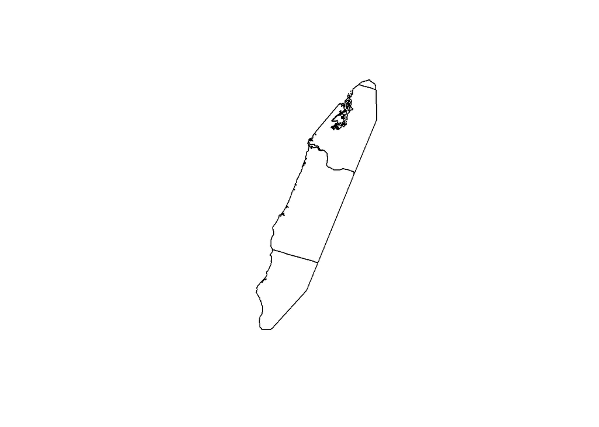

```r
sp_clean_sf_hull<-st_intersection(sp_clean_sf_hull,st)
plot(sp_clean_sf_hull)
```

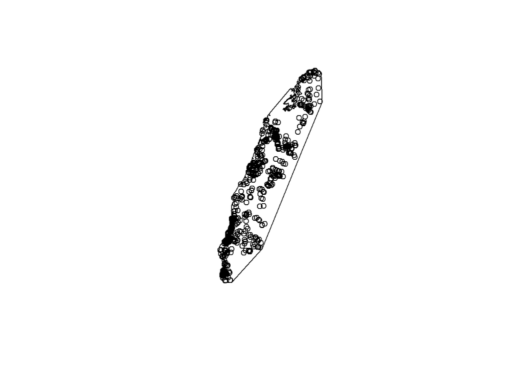

```r
sp_clean_sf_hull<-st_union(sp_clean_sf_hull)


plot(sp_clean_sf_hull)


plot(sp_clean_sf_hull)
plot(sp_clean_sf_multi, add=T)
```

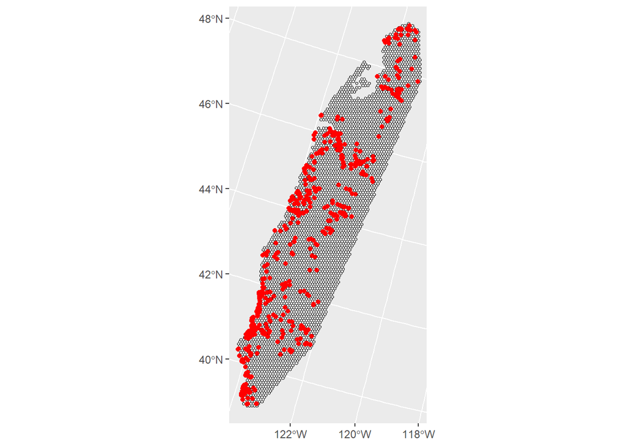

```r
## Cell Size



cellarea<-40e6
cellsize<-2 * sqrt(cellarea/((3*sqrt(3)/2))) * sqrt(3)/2

## Grid!



  grid <- st_make_grid(x = sp_clean_sf_hull,
               cellsize = cellsize,
               square = F) %>%
    st_sf()%>%
    st_intersection(sp_clean_sf_hull)%>%
     mutate(area_m2 = st_area(geometry)) %>%
     filter(area_m2 > max(area_m2)-set_units(1, m^2)) %>%
       mutate(grid.id = row_number())


ggplot()+
  geom_sf(data=grid,colour="black")+
  geom_sf(data=sp_clean_sf,colour="red")+
    coord_sf(xlim = bb[c("xmin", "xmax")], ylim =  bb[c("ymin", "ymax")])
```

```r
  save(grid, file = "data_processed/grid_d.tenebrosus.rdata")
```

### Working with Raster and Vector Data

Here we summarize environmental covariates (habitat data) to the species grid.

```r
prec_files <- list.files("data_raw/clim/climate/wc2.1_30s", pattern = "wc2.1_30s_prec_\\d+\\.tif$", full.names = TRUE)



prec_stack <- rast(prec_files)


prec_yr <- sum(prec_stack)
```

```
## |---------|---------|---------|---------|=========================================
```

```r
names(prec_yr)<-"Precip.Total"


tmax_files <- list.files("data_raw/clim/climate/wc2.1_30s", pattern = "wc2.1_30s_tmax_\\d+\\.tif$", full.names = TRUE)



tmax_stack <- rast(tmax_files)[[5:8]]


tmax_summer <- sum(tmax_stack)
```

```
## |---------|---------|---------|---------|=========================================
```

```r
names(tmax_summer)<-"Summer.Temp.Maximum"

clim_stack<-c(tmax_summer,prec_yr)




crs(clim_stack)
```

```
## [1] "GEOGCRS[\"WGS 84\",\n    ENSEMBLE[\"World Geodetic System 1984 ensemble\",\n        MEMBER[\"World Geodetic System 1984 (Transit)\"],\n        MEMBER[\"World Geodetic System 1984 (G730)\"],\n        MEMBER[\"World Geodetic System 1984 (G873)\"],\n        MEMBER[\"World Geodetic System 1984 (…
```

```r
sf::st_crs(sp_clean_sf_hull)==sf::st_crs(clim_stack)
```

```
## [1] FALSE
```

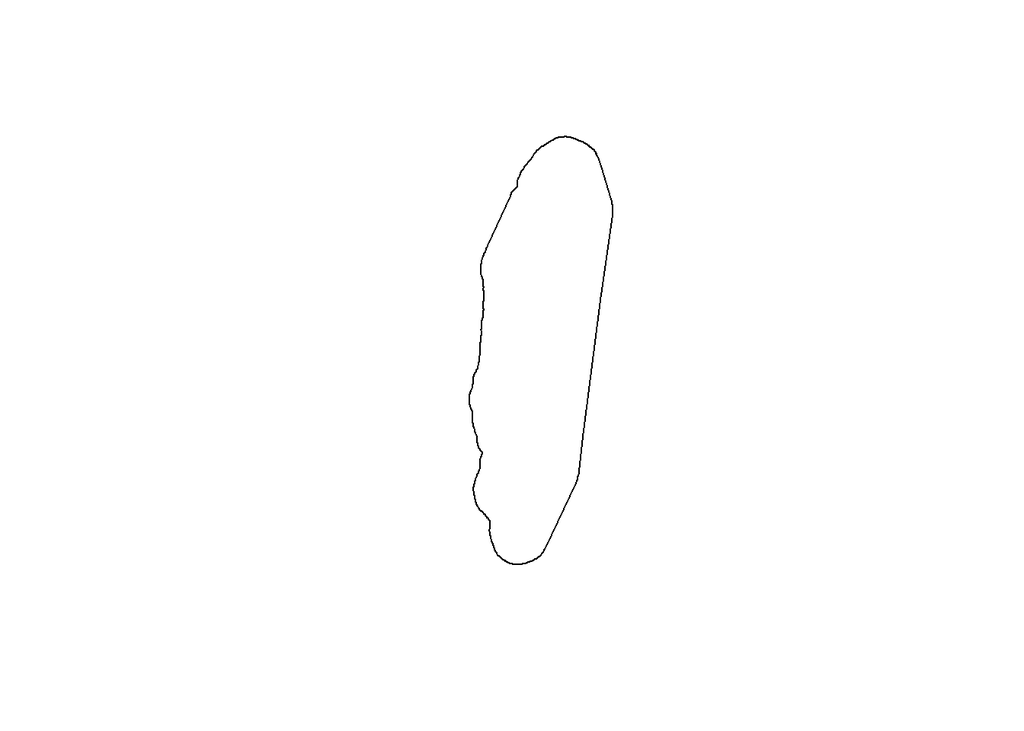

```r
hull.crop<-sp_clean_sf_hull%>%
  st_buffer(60000)%>%
  st_transform(crs = st_crs(clim_stack))

plot(hull.crop)
```

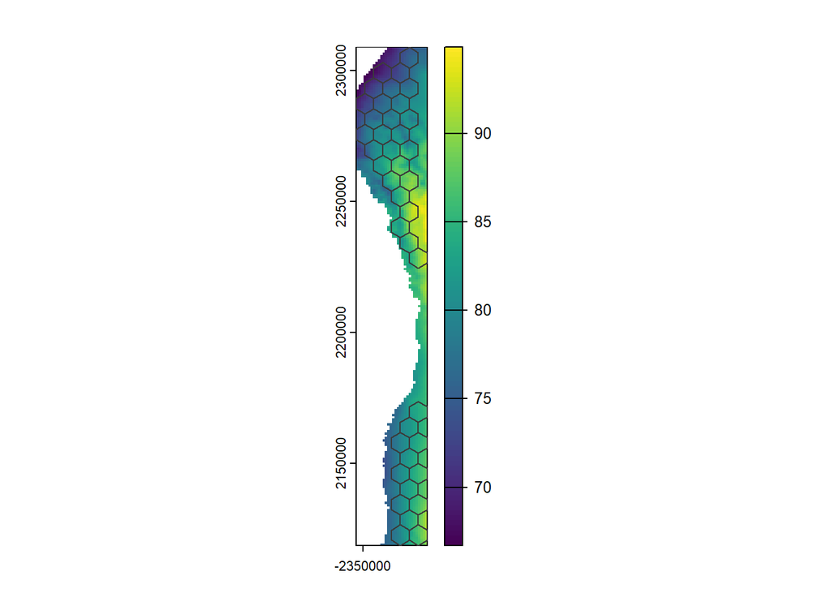

```r
bb.cov<-st_bbox(hull.crop)


clim.stack1 <- terra::crop(clim_stack, bb.cov)


clim.stack2 <- clim.stack1 %>%
    project(crs(grid), method="bilinear")



bb.cells<-st_bbox(grid[1:40,])


plot(clim.stack2[[1]], xlim = bb.cells[c("xmin", "xmax")], ylim = bb.cells[c("ymin", "ymax")], axes = TRUE)
plot(sf::st_geometry(grid[1:40,]), col = NA, border = "grey23", add = TRUE)
```

```r
covs <- terra::zonal(clim.stack2,
                        terra::vect(grid),
                        fun="mean",na.rm=T,
                        weights=T)%>%
    mutate(grid.id = grid$grid.id)
```

### Working with Vector and Vector Data

Here we summarize species occurrences to the species grid and join all data together.

```r
sp.agg <- grid %>%
  mutate(count.to.bin = lengths(st_intersects(grid, sp_clean_sf)))

nrow(sp.agg)==nrow(covs)
```

```
## [1] TRUE
```

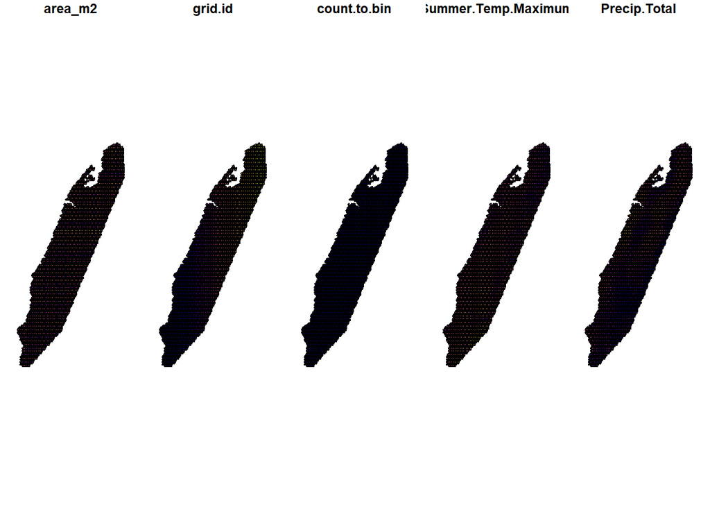

```r
all<-left_join(sp.agg,covs, by="grid.id")

plot(all)
```

## Assessing Correlation

### Checking for simple correlation between species data and and covariate data

Normally, we would want to use something a bit more flexible like such as some sort of regression model where we could use habitat information to explain species occurrences. For simplicity, we just check for correlation between our covariates and the species data.

```r
all%>%
select(Summer.Temp.Maximum,Precip.Total,count.to.bin) %>%
  mutate(across(everything(), as.numeric)) %>%
  cor(method = 'spearman', use = "pairwise.complete.obs")
```

```
##                     Summer.Temp.Maximum Precip.Total count.to.bin geometry
## Summer.Temp.Maximum          1.00000000   -0.6618930  -0.04930532       NA
## Precip.Total                -0.66189296    1.0000000   0.11581739       NA
## count.to.bin                -0.04930532    0.1158174   1.00000000       NA
## geometry                             NA           NA           NA       NA
```

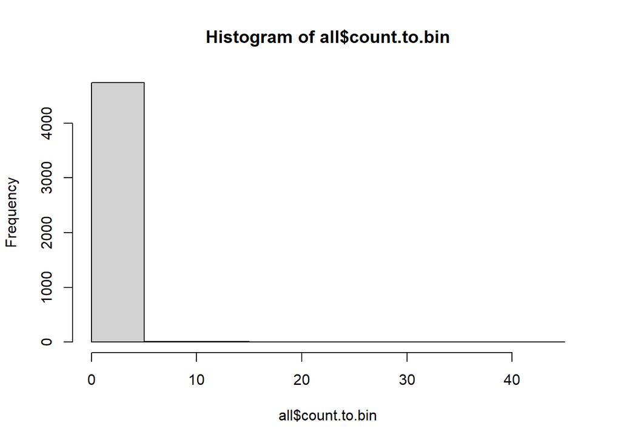

```r
hist(all$count.to.bin)
```

### Checking for spatial autocorrelation in the temperature covariate

This is an important step in deciding whether we will need to model the relationships between the covariates and the species data using an explicitly spatial statistical model.

```r
nb <- all%>%
  poly2nb(queen=TRUE)
nb[52]
```

```
## [[1]]
## [1] 39 67 68 85
```

```r
lw <- nb2listw(nb, style="W", zero.policy=TRUE)


lw$weights[52]
```

```
## [[1]]
## [1] 0.25 0.25 0.25 0.25
```

```r
moran.test(all$Summer.Temp.Maximum,listw=lw, alternative="greater")
```

```
##
##  Moran I test under randomisation
##
## data:  all$Summer.Temp.Maximum
## weights: lw
## n reduced by no-neighbour observations
##
## Moran I statistic standard deviate = 106.04, p-value < 2.2e-16
## alternative hypothesis: greater
## sample estimates:
## Moran I statistic       Expectation          Variance
##      9.105069e-01     -2.102165e-04      7.375972e-05
```